# Autoencoders in R — Representation Learning, Denoising, and Anomaly Detection with Keras3

# Autoencoders: theory and use cases

An **autoencoder** is a neural network trained to reconstruct its input:
$$f_\theta: x \mapsto \hat{x}$$
with architecture split into:

- **Encoder** $E_\phi$: maps input $x \in \mathbb{R}^p$ to a **latent code** $z \in \mathbb{R}^d$, usually with $d < p$
  $$z = E_\phi(x)$$
- **Decoder** $D_\psi$: maps code $z$ back to a reconstruction $\hat{x}$
  $$\hat{x} = D_\psi(z)$$

The overall model minimizes a **reconstruction loss**, e.g. mean squared error:
$$\mathcal{L}(\phi,\psi) = \frac{1}{n}\sum_{i=1}^n \| x_i -
D_\psi(E_\phi(x_i)) \|_2^2$$

Deep autoencoders use multiple layers in encoder and decoder, allowing **non-linear representation learning**.

Typical uses:

- **Non-linear dimensionality reduction** (latent code as learned features).
- **Denoising**: reconstruct clean signals from noisy inputs.
- **Anomaly detection**: high reconstruction error as a proxy for “unusual” patterns.
- **Pretraining**: initialize deep architectures with unsupervised features.

In this lesson we use the **Wholesale Customers** dataset (spending by product category) to:

- Fit an autoencoder to learn a low-dimensional representation of spending profiles.
- Compare latent codes to PCA.
- Use reconstruction error for anomaly-style analysis.

# Step 1: Data import and preprocessing

```r
local_path <- "raw_data/wholesale_customers.csv"
url_path <- "https://raw.githubusercontent.com/SobiaNoorAI/Wholesale-Customer-Segmentation-and-Spending-Behavior-Analysis-By-ML/main/Data/Wholesale%20customers%20data.csv"

if (!file.exists(local_path)) {
  dir.create("raw_data", showWarnings = FALSE)
  download.file(url_path, local_path, mode = "wb")
}

wholesale <- read_csv(local_path, show_col_types = FALSE)
glimpse(wholesale)
```

```
## Rows: 440
## Columns: 8
## $ Channel          <dbl> 2, 2, 2, 1, 2, 2, 2, 2, 1, 2, 2, 2, 2, 2, 2, 1, 2, 1, 2, 1, 2, 1, 1, 2, 2, 2, 1, 1, 2,…
## $ Region           <dbl> 3, 3, 3, 3, 3, 3, 3, 3, 3, 3, 3, 3, 3, 3, 3, 3, 3, 3, 3, 3, 3, 3, 3, 3, 3, 3, 3, 3, 3,…
## $ Fresh            <dbl> 12669, 7057, 6353, 13265, 22615, 9413, 12126, 7579, 5963, 6006, 3366, 13146, 31714, 21…
## $ Milk             <dbl> 9656, 9810, 8808, 1196, 5410, 8259, 3199, 4956, 3648, 11093, 5403, 1124, 12319, 6208, …
## $ Grocery          <dbl> 7561, 9568, 7684, 4221, 7198, 5126, 6975, 9426, 6192, 18881, 12974, 4523, 11757, 14982…
## $ Frozen           <dbl> 214, 1762, 2405, 6404, 3915, 666, 480, 1669, 425, 1159, 4400, 1420, 287, 3095, 294, 39…
## $ Detergents_Paper <dbl> 2674, 3293, 3516, 507, 1777, 1795, 3140, 3321, 1716, 7425, 5977, 549, 3881, 6707, 5058…
## $ Delicassen       <dbl> 1338, 1776, 7844, 1788, 5185, 1451, 545, 2566, 750, 2098, 1744, 497, 2931, 602, 2168, …
```

Focus on the numeric spending variables:

```r
spend_vars <- c("Fresh", "Milk", "Grocery", "Frozen", "Detergents_Paper", "Delicassen")

X_raw <- wholesale |>
  select(all_of(spend_vars)) |>
  na.omit()

summary(X_raw)
```

```
##      Fresh             Milk          Grocery          Frozen        Detergents_Paper    Delicassen
##  Min.   :     3   Min.   :   55   Min.   :    3   Min.   :   25.0   Min.   :    3.0   Min.   :    3.0
##  1st Qu.:  3128   1st Qu.: 1533   1st Qu.: 2153   1st Qu.:  742.2   1st Qu.:  256.8   1st Qu.:  408.2
##  Median :  8504   Median : 3627   Median : 4756   Median : 1526.0   Median :  816.5   Median :  965.5
##  Mean   : 12000   Mean   : 5796   Mean   : 7951   Mean   : 3071.9   Mean   : 2881.5   Mean   : 1524.9
##  3rd Qu.: 16934   3rd Qu.: 7190   3rd Qu.:10656   3rd Qu.: 3554.2   3rd Qu.: 3922.0   3rd Qu.: 1820.2
##  Max.   :112151   Max.   :73498   Max.   :92780   Max.   :60869.0   Max.   :40827.0   Max.   :47943.0
```

Spending is strongly right-skewed. We apply $\log(1+x)$ and standardization:

```r
X_log <- X_raw |>
  mutate(across(everything(), log1p))

means <- sapply(X_log, mean)
sds   <- sapply(X_log, sd)

X <- X_log |>
  mutate(across(everything(), ~ (.x - means[cur_column()]) / sds[cur_column()]))

X_mat <- as.matrix(X)
dim(X_mat)
```

```
## [1] 440   6
```

We will train the autoencoder **only** on this standardized matrix.

# Step 2: Train/validation split (unsupervised)

Even though there is no target, we still need a **validation set** to detect overfitting.

```r
set.seed(123)

n <- nrow(X_mat)
idx <- sample.int(n)
train_frac <- 0.8
n_train <- floor(train_frac * n)

X_train <- X_mat[idx[1:n_train], , drop = FALSE]
X_valid <- X_mat[idx[(n_train + 1):n], , drop = FALSE]

dim(X_train)
```

```
## [1] 352   6
```

```r
dim(X_valid)
```

```
## [1] 88  6
```

# Step 3: Autoencoder architecture design

We choose a **symmetric deep autoencoder**:

- Input dimension $p = 6$ (spending categories).
- Encoder:
  - Dense(64) → Dense(32) → Dense($d$) where $d = 2$ (latent code).
- Decoder:
  - Dense(32) → Dense(64) → Dense(6).

We use:

- ReLU activations in hidden layers.
- Linear activation in the output (since data are standardized and roughly continuous).
- MSE loss as reconstruction loss.
- Optional L2 regularization and dropout in the encoder to prevent trivial memorization.

Mathematically:
$$z = \sigma(W_2 \sigma(W_1 x + b_1) + b_2), \quad
\hat{x} = W_4 \sigma(W_3 z + b_3) + b_4$$

with $\sigma$ = ReLU and loss $\frac{1}{n}\sum_i \|x_i - \hat{x}_i\|^2$.

# Step 4: Implement the autoencoder in keras3

```r
input_dim <- ncol(X_train)
latent_dim <- 2L

build_autoencoder <- function(input_dim, latent_dim,
                              l2_lambda = 1e-4, dropout_rate = 0.1) {

  input <- layer_input(shape = input_dim, name = "input_layer")

  # Encoder
  encoded <- input |>
    layer_dense(units = 64, activation = "relu",
                kernel_regularizer = regularizer_l2(l2_lambda)) |>
    layer_dropout(rate = dropout_rate) |>
    layer_dense(units = 32, activation = "relu",
                kernel_regularizer = regularizer_l2(l2_lambda)) |>
    layer_dense(units = latent_dim, activation = "linear", name = "latent_code")

  # Decoder
  decoded <- encoded |>
    layer_dense(units = 32, activation = "relu",
                kernel_regularizer = regularizer_l2(l2_lambda)) |>
    layer_dense(units = 64, activation = "relu",
                kernel_regularizer = regularizer_l2(l2_lambda)) |>
    layer_dense(units = input_dim, activation = "linear", name = "reconstruction")

  autoencoder <- keras_model(inputs = input, outputs = decoded)

  autoencoder |>
    compile(
      optimizer = optimizer_adam(learning_rate = 1e-3),
      loss = "mse"
    )

  autoencoder
}

autoencoder <- build_autoencoder(input_dim, latent_dim)
autoencoder
```

```
## Model: "functional_3"
## ┏━━━━━━━━━━━━━━━━━━━━━━━━━━━━━━━━━━━━━━━━━━━━━━━━━┳━━━━━━━━━━━━━━━━━━━━━━━━━━━━━━━━━━━━━━┳━━━━━━━━━━━━━━━━━━━━━━┓
## ┃ Layer (type)                                    ┃ Output Shape                         ┃              Param # ┃
## ┡━━━━━━━━━━━━━━━━━━━━━━━━━━━━━━━━━━━━━━━━━━━━━━━━━╇━━━━━━━━━━━━━━━━━━━━━━━━━━━━━━━━━━━━━━╇━━━━━━━━━━━━━━━━━━━━━━┩
## │ input_layer (InputLayer)                        │ (None, 6)                            │                    0 │
## ├─────────────────────────────────────────────────┼──────────────────────────────────────┼──────────────────────┤
## │ dense_5 (Dense)                                 │ (None, 64)                           │                  448 │
## ├─────────────────────────────────────────────────┼──────────────────────────────────────┼──────────────────────┤
## │ dropout_2 (Dropout)                             │ (None, 64)                           │                    0 │
## ├─────────────────────────────────────────────────┼──────────────────────────────────────┼──────────────────────┤
## │ dense_6 (Dense)                                 │ (None, 32)                           │                2,080 │
## ├─────────────────────────────────────────────────┼──────────────────────────────────────┼──────────────────────┤
## │ latent_code (Dense)                             │ (None, 2)                            │                   66 │
## ├─────────────────────────────────────────────────┼──────────────────────────────────────┼──────────────────────┤
## │ dense_7 (Dense)                                 │ (None, 32)                           │                   96 │
## ├─────────────────────────────────────────────────┼──────────────────────────────────────┼──────────────────────┤
## │ dense_8 (Dense)                                 │ (None, 64)                           │                2,112 │
## ├─────────────────────────────────────────────────┼──────────────────────────────────────┼──────────────────────┤
## │ reconstruction (Dense)                          │ (None, 6)                            │                  390 │
## └─────────────────────────────────────────────────┴──────────────────────────────────────┴──────────────────────┘
##  Total params: 5,192 (20.28 KB)
##  Trainable params: 5,192 (20.28 KB)
##  Non-trainable params: 0 (0.00 B)
```

We can also define a standalone **encoder model** to map $x \mapsto z$:

```r
encoder <- keras_model(
  inputs = autoencoder$input,
  outputs = autoencoder$get_layer("latent_code")$output
)
encoder
```

```
## Model: "functional_4"
## ┏━━━━━━━━━━━━━━━━━━━━━━━━━━━━━━━━━━━━━━━━━━━━━━━━━┳━━━━━━━━━━━━━━━━━━━━━━━━━━━━━━━━━━━━━━┳━━━━━━━━━━━━━━━━━━━━━━┓
## ┃ Layer (type)                                    ┃ Output Shape                         ┃              Param # ┃
## ┡━━━━━━━━━━━━━━━━━━━━━━━━━━━━━━━━━━━━━━━━━━━━━━━━━╇━━━━━━━━━━━━━━━━━━━━━━━━━━━━━━━━━━━━━━╇━━━━━━━━━━━━━━━━━━━━━━┩
## │ input_layer (InputLayer)                        │ (None, 6)                            │                    0 │
## ├─────────────────────────────────────────────────┼──────────────────────────────────────┼──────────────────────┤
## │ dense_5 (Dense)                                 │ (None, 64)                           │                  448 │
## ├─────────────────────────────────────────────────┼──────────────────────────────────────┼──────────────────────┤
## │ dropout_2 (Dropout)                             │ (None, 64)                           │                    0 │
## ├─────────────────────────────────────────────────┼──────────────────────────────────────┼──────────────────────┤
## │ dense_6 (Dense)                                 │ (None, 32)                           │                2,080 │
## ├─────────────────────────────────────────────────┼──────────────────────────────────────┼──────────────────────┤
## │ latent_code (Dense)                             │ (None, 2)                            │                   66 │
## └─────────────────────────────────────────────────┴──────────────────────────────────────┴──────────────────────┘
##  Total params: 2,594 (10.13 KB)
##  Trainable params: 2,594 (10.13 KB)
##  Non-trainable params: 0 (0.00 B)
```

# Step 5: Train the autoencoder with early stopping

```r
callback_es <- callback_early_stopping(
  monitor = "val_loss",
  patience = 10,
  restore_best_weights = TRUE
)

set.seed(123)
history <- autoencoder |>
  fit(
    x = X_train,
    y = X_train,               # target = input
    validation_data = list(X_valid, X_valid),
    epochs = 200,
    batch_size = 64,
    callbacks = list(callback_es),
    verbose = 2
  )
```

Learning curve:

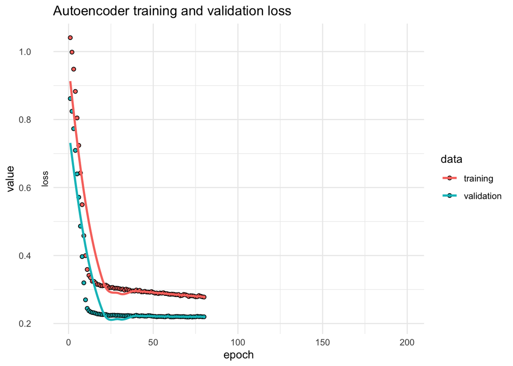

```r
plot(history) +
  theme_minimal() +
  ggtitle("Autoencoder training and validation loss")
```

We want training and validation losses to converge to a low value without strong divergence, which would signal overfitting to idiosyncratic patterns.

# Step 6: Latent representation vs PCA

Compute latent codes for all observations:

```r
Z <- encoder |>
  predict(X_mat)

latent_df <- data.frame(
  z1 = Z[, 1],
  z2 = Z[, 2]
)

head(latent_df)
```

| z1 | z2 |
| --- | --- |
| -0.4417788 | 1.7300138 |
| 0.4743341 | 2.4331424 |
| 1.0019404 | 2.9899631 |
| 1.9196881 | -0.0989299 |
| 1.7836455 | 2.3567364 |
| -0.0447464 | 1.2960854 |

Compare with a 2D PCA projection:

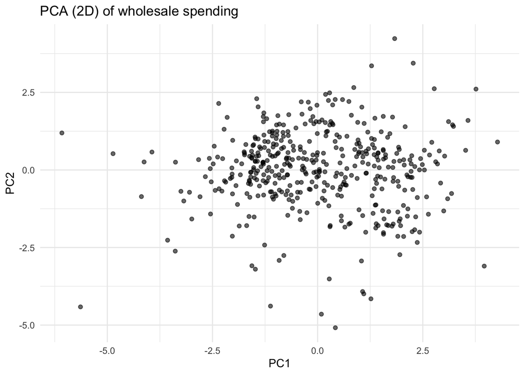

```r
pc <- prcomp(X_mat)
pc_df <- data.frame(
  PC1 = pc$x[, 1],
  PC2 = pc$x[, 2]
)

# Plot PCA vs autoencoder codes
p1 <- ggplot(pc_df, aes(PC1, PC2)) +
  geom_point(alpha = 0.6) +
  theme_minimal() +
  ggtitle("PCA (2D) of wholesale spending")

p2 <- ggplot(latent_df, aes(z1, z2)) +
  geom_point(alpha = 0.6, color = "steelblue") +
  theme_minimal() +
  ggtitle("Autoencoder latent space (2D)")

p1
```

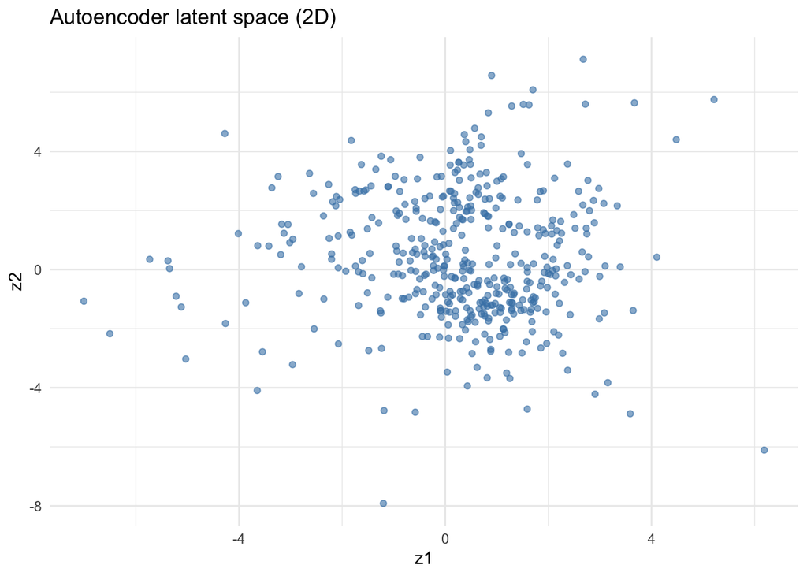

```r
p2
```

Discussion:

- PCA finds a **linear** 2D subspace that maximizes variance.
- The autoencoder learns a **non-linear** mapping to 2D, optimized for reconstruction rather than variance.
- Clusters or curved manifolds may appear more clearly in the autoencoder space, especially with more complex architectures.

You can also examine how each latent dimension relates to original features via correlation:

```r
cor(cbind(latent_df, X_mat))
```

```
##                           z1          z2       Fresh        Milk    Grocery      Frozen Detergents_Paper
## z1                1.00000000 -0.01124613  0.76648757 -0.14774319 -0.3525622  0.72284490       -0.3609554
## z2               -0.01124613  1.00000000  0.06621823  0.88090330  0.8665913  0.02941615        0.8050640
## Fresh             0.76648757  0.06621823  1.00000000 -0.02109638 -0.1329889  0.38625790       -0.1587060
## Milk             -0.14774319  0.88090330 -0.02109638  1.00000000  0.7611276 -0.05522851        0.6787248
## Grocery          -0.35256221  0.86659126 -0.13298890  0.76112760  1.0000000 -0.16452522        0.7971412
## Frozen            0.72284490  0.02941615  0.38625790 -0.05522851 -0.1645252  1.00000000       -0.2127709
## Detergents_Paper -0.36095537  0.80506395 -0.15870598  0.67872480  0.7971412 -0.21277086        1.0000000
## Delicassen        0.51135379  0.56015721  0.25644186  0.34231006  0.2399975  0.25631819        0.1675729
##                  Delicassen
## z1                0.5113538
## z2                0.5601572
## Fresh             0.2564419
## Milk              0.3423101
## Grocery           0.2399975
## Frozen            0.2563182
## Detergents_Paper  0.1675729
## Delicassen        1.0000000
```

# Step 7: Reconstruction error and anomaly-style analysis

For each observation, the reconstruction error is
$$e_i = \| x_i - \hat{x}_i \|_2^2$$
which we can compute on the standardized scale.

```r
X_hat <- autoencoder |>
  predict(X_mat)

recon_error <- rowSums((X_mat - X_hat)^2)

summary(recon_error)
```

```
##     Min.  1st Qu.   Median     Mean  3rd Qu.     Max.
##  0.04672  0.44954  0.89665  1.51253  1.68348 19.81549
```

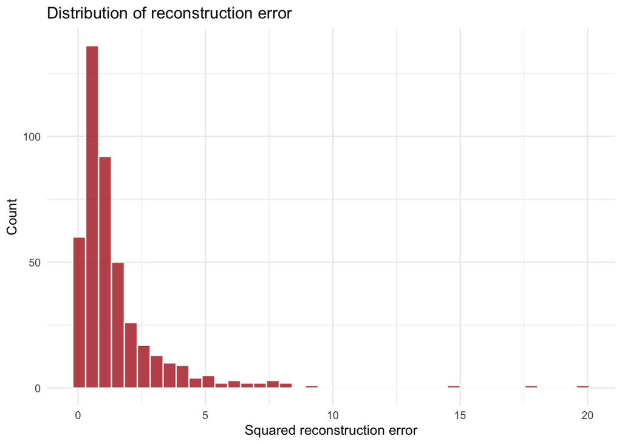

```r
error_df <- data.frame(
  error = recon_error
)

ggplot(error_df, aes(x = error)) +
  geom_histogram(bins = 40, fill = "firebrick", alpha = 0.8, color = "white") +
  theme_minimal() +
  labs(
    title = "Distribution of reconstruction error",
    x = "Squared reconstruction error",
    y = "Count"
  )
```

A simple heuristic for “potential anomalies” is to flag observations in the upper tail of the reconstruction error distribution (e.g., top 5–10%).

```r
threshold <- quantile(recon_error, 0.95)
idx_anom <- which(recon_error >= threshold)

length(idx_anom) / n  # proportion flagged
```

```
## [1] 0.05
```

```r
head(X_raw[idx_anom, ])
```

| Fresh | Milk | Grocery | Frozen | Detergents_Paper | Delicassen |
| --- | --- | --- | --- | --- | --- |
| 4591 | 15729 | 16709 | 33 | 6956 | 433 |
| 10850 | 7555 | 14961 | 188 | 6899 | 46 |
| 18291 | 1266 | 21042 | 5373 | 4173 | 14472 |
| 20398 | 1137 | 3 | 4407 | 3 | 975 |
| 717 | 3587 | 6532 | 7530 | 529 | 894 |
| 7864 | 542 | 4042 | 9735 | 165 | 46 |

Caveats:

- A high reconstruction error can identify unusual spending profiles, but autoencoders are **not guaranteed** to fail on anomalies; in some cases they reconstruct them surprisingly well.
- It is safer to treat reconstruction error as one feature among others in an anomaly pipeline, not as a stand-alone detector.

# Step 8: Denoising autoencoder variant

A **denoising autoencoder** receives noisy inputs $\tilde{x} = x + \epsilon$ as input, but learns to reconstruct the **clean** $x$. The training objective becomes
$$\mathcal{L} = \frac{1}{n}\sum_i \| x_i - D_\psi(E_\phi(\tilde{x}_i))
\|^2$$
which forces the model to learn a representation robust to noise.

We can simulate noise by adding Gaussian perturbations during training.

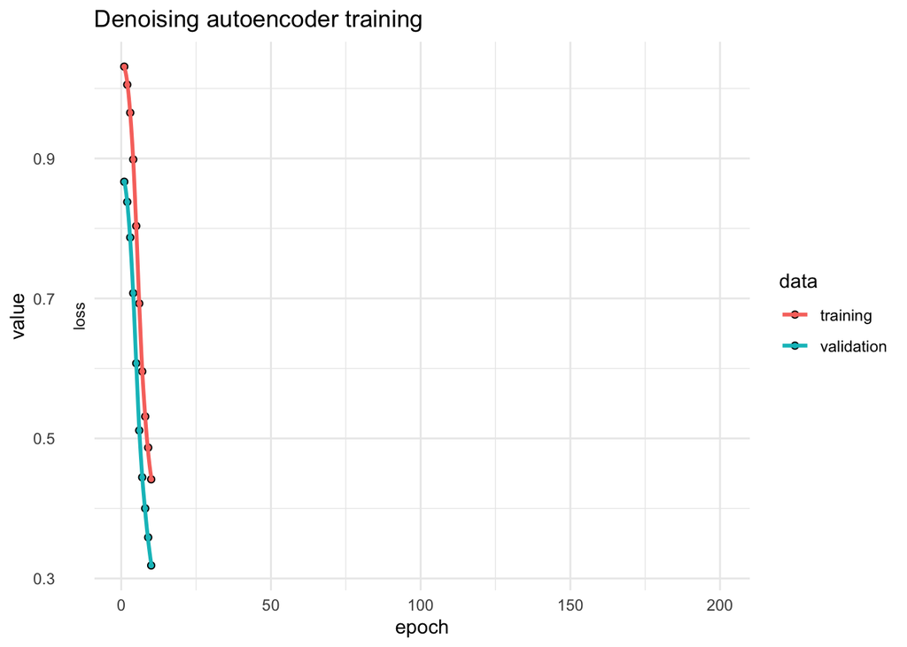

```r
set.seed(123)

add_noise <- function(X, noise_sd = 0.2) {
  X + matrix(rnorm(length(X), mean = 0, sd = noise_sd), nrow = nrow(X))
}

X_train_noisy <- add_noise(X_train, noise_sd = 0.2)
X_valid_noisy <- add_noise(X_valid, noise_sd = 0.2)

denoising_ae <- build_autoencoder(input_dim, latent_dim,
                                  l2_lambda = 1e-4, dropout_rate = 0.0)

history_denoise <- denoising_ae |>
  fit(
    x = X_train_noisy,
    y = X_train,   # target = clean input
    validation_data = list(X_valid_noisy, X_valid),
    epochs = 200,
    batch_size = 64,
    callbacks = list(callback_es),
    verbose = 0
  )

plot(history_denoise) +
  theme_minimal() +
  ggtitle("Denoising autoencoder training")
```

The denoising autoencoder tends to learn codes that emphasize **stable structure**, improving robustness for downstream tasks (e.g., clustering on the latent space).

# Step 9: Autoencoder codes as features for clustering

We can use the latent representation $z$ as input to clustering algorithms (e.g., K-means) to obtain segmentations in a low-dimensional, non-linear feature space.

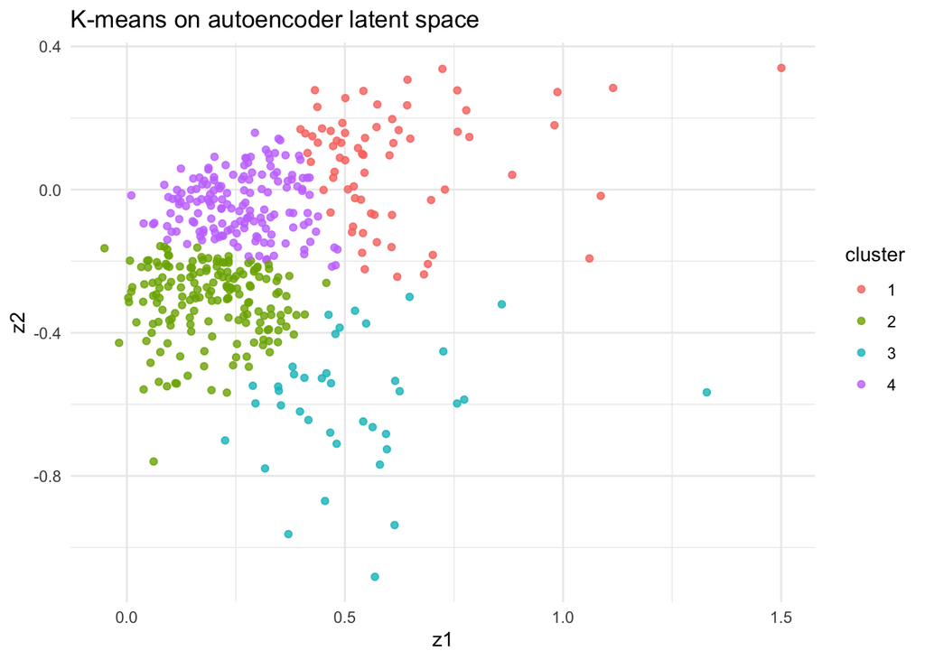

```r
# Build encoder model once from the existing autoencoder
encoder_denoise <- keras_model(
  inputs  = denoising_ae$input,
  outputs = denoising_ae$get_layer("latent_code")$output
)

# Now get latent codes for all observations
Z_all <- encoder_denoise |>
  predict(X_mat)

set.seed(123)
km_latent <- kmeans(Z_all, centers = 4, nstart = 50)

latent_cluster_df <- data.frame(
  z1 = Z_all[, 1],
  z2 = Z_all[, 2],
  cluster = factor(km_latent$cluster)
)

ggplot(latent_cluster_df, aes(z1, z2, color = cluster)) +
  geom_point(alpha = 0.8) +
  theme_minimal() +
  labs(
    title = "K-means on autoencoder latent space",
    x = "z1", y = "z2"
  )
```

Comparing this clustering to K-means on the original standardized space can reveal whether the autoencoder has highlighted meaningful non-linear structure.

# Step 10: Summary of autoencoder use cases

Autoencoders are versatile tools for:

- **Non-linear dimensionality reduction**: learn compact codes for complex multivariate data.
- **Feature learning for downstream tasks**: use latent codes as input to clustering, classification, or regression models.
- **Denoising**: learn representations that are robust to noise and small perturbations.
- **Reconstruction-based anomaly analysis**: use reconstruction error as a signal of unusual patterns (with appropriate caution and validation).
- **Pretraining**: initialize deep models on unlabeled data before supervised fine-tuning.

In this lesson you:

- Implemented a deep autoencoder in R using keras3 and TensorFlow.
- Learned how to design encoder/decoder architectures and choose latent dimensionality.
- Used early stopping and validation for unsupervised training.
- Compared autoencoder latent space to PCA.
- Explored reconstruction error and denoising variants, and used autoencoder codes as inputs for clustering.

A work by [Gianluca Sottile](https://www.unipa.it/persone/docenti/s/gianluca.sottile)

*gianluca.sottile@unipa.it*